# 01 data_creation

21/02/2025

Clear global environment prior to initiation

```r
remove(list = ls())
```

Read in file with path to ilovedata channel on Teams Ensure that your credentials directory is correctly located

```r
source(file = "credentials/paths.R")
```

Add the add_numeric function - used to convert character variables into numeric variables. Add the sumscores function - used to generate sumscores Add the package_check function - used to install and load dependencies

```r
source(file = paste0(ilovedata_scripts, "functions/add_numeric.R"))
source(file = paste0(ilovedata_scripts, "functions/remove_duplicates.R"))
source(file = paste0(ilovedata_scripts, "functions/sumscores.R"))
source(file = paste0(ilovedata_scripts, "functions/package_check.R"))
source(file = paste0(ilovedata_scripts, "functions/imp_check.R"))
source(file = paste0(ilovedata_scripts, "functions/recode_check.R"))
```

Load packages

```r
library(summarytools)
library(tidyverse)
```

Retrieve the recent date

```r
date = Sys.Date()
date
```

```
[1] "2025-03-17"
```

# 1 Join questionnaires

## 1.1 Rds files to read in

- age_glad_clean.rds
- signup_bmi_height_weight_glad_clean.rds
- employment_glad_clean.rds
- ethnicity_glad_clean.rds
- gad7_glad_clean.rds
- highest_education_glad_clean.rds
- mhd_glad_clean.rds
- phq9_glad_clean.rds
- sex_gender_sexuality_glad_clean.rds

## 1.2 File path

```r
data_path <- filepath_data_raw
```

## 1.3 Read file names of rds files

```r
files <- dir(
  path = data_path, # Folder with cleaned data for this project (copied from ilovedata)
  pattern = "*rds"
  )
files
```

```
[1] "age_glad_clean.rds"
[2] "employment_glad_clean.rds"
[3] "ethnicity_glad_clean.rds"
[4] "gad7_glad_clean.rds"
[5] "highest_education_glad_clean.rds"
[6] "mhd_glad_clean.rds"
[7] "phq9_glad_clean.rds"
[8] "sex_gender_sexuality_glad_clean.rds"
[9] "signup_bmi_height_weight_glad_clean.rds"
```

## 1.4 Join rds files together

+++CH: Need to manage to remove startDate and endDate so not a million .x.x.x get added to variable names

```r
dat <- files %>%
  map(~ read_rds(file.path(data_path, .))) %>%
  reduce(
    full_join,
    by = c("ID", "sample")
    )
```

## 1.5 Check for duplicates

```r
dat %>% group_by(ID) %>% filter(n()>1) %>% summarize(n=n())
```

| ID | n |
| --- | --- |

## 1.6 Variable names

```r
dat %>% names
```

```
  [1] "ID"
  [2] "startDate.x"
  [3] "endDate.x"
  [4] "sample"
  [5] "dem.how_old_are_you_now.txt"
  [6] "dem.dob_age"
  [7] "dem.age_match"
  [8] "dem.age_likely"
  [9] "dem.age_category"
 [10] "dem.age_category_numeric"
 [11] "startDate.y"
 [12] "endDate.y"
 [13] "dem.what_is_your_current_employment_status"
 [14] "dem.what_is_your_current_employment_status_numeric"
 [15] "startDate.x.x"
```

[output cut: 256 more lines]

The tibble has no duplicates.

# 2 Vectors

## 2.1 GAD7 items vector

```r
gad7_items_numeric <-
  c(
  "gad7.feeling_nervous_anxious_or_on_edge_numeric",
  "gad7.control_worrying_stop_numeric",
  "gad7.worrying_too_much_about_different_things_numeric",
  "gad7.trouble_relaxing_numeric",
  "gad7.sit_restless_hard_numeric",
  "gad7.becoming_easily_annoyed_or_irritable_numeric",
  "gad7.awful_feeling_afraid_happen_numeric"
  )
```

## 2.2 PHQ9 items vector

```r
phq9_items_numeric <-
  c(
  "phq9.dead_hurting_thoughts_numeric",
  "phq9.feeling_bad_failure_family_numeric",
  "phq9.feeling_down_depressed_or_hopeless_numeric",
  "phq9.feeling_tired_or_having_little_energy_numeric",
  "phq9.little_interest_or_pleasure_in_doing_things_numeric",
  "phq9.moving_fidgety_noticed_opposite_numeric",
  "phq9.poor_appetite_or_overeating_numeric",
  "phq9.staying_asleep_sleeping_trouble_numeric",
  "phq9.trouble_concentrating_reading_newspaper_numeric"
  )

phq9_items <-
  c(
  "phq9.dead_hurting_thoughts",
  "phq9.feeling_bad_failure_family",
  "phq9.feeling_down_depressed_or_hopeless",
  "phq9.feeling_tired_or_having_little_energy",
  "phq9.little_interest_or_pleasure_in_doing_things",
  "phq9.moving_fidgety_noticed_opposite",
  "phq9.poor_appetite_or_overeating",
  "phq9.staying_asleep_sleeping_trouble",
  "phq9.trouble_concentrating_reading_newspaper"
  )
```

# 3 dat_gad7

```r
dat_gad7 <- dat %>%
  select(
    all_of(gad7_items_numeric)
  ) %>%
  as.data.frame()

dat_gad7 %>% names
```

```
[1] "gad7.feeling_nervous_anxious_or_on_edge_numeric"
[2] "gad7.control_worrying_stop_numeric"
[3] "gad7.worrying_too_much_about_different_things_numeric"
[4] "gad7.trouble_relaxing_numeric"
[5] "gad7.sit_restless_hard_numeric"
[6] "gad7.becoming_easily_annoyed_or_irritable_numeric"
[7] "gad7.awful_feeling_afraid_happen_numeric"
```

# 4 dat_phq9

```r
dat_phq9 <- dat %>%
  select(
    all_of(phq9_items_numeric)
  ) %>%
  as.data.frame()

dat_phq9 %>% names
```

```
[1] "phq9.dead_hurting_thoughts_numeric"
[2] "phq9.feeling_bad_failure_family_numeric"
[3] "phq9.feeling_down_depressed_or_hopeless_numeric"
[4] "phq9.feeling_tired_or_having_little_energy_numeric"
[5] "phq9.little_interest_or_pleasure_in_doing_things_numeric"
[6] "phq9.moving_fidgety_noticed_opposite_numeric"
[7] "phq9.poor_appetite_or_overeating_numeric"
[8] "phq9.staying_asleep_sleeping_trouble_numeric"
[9] "phq9.trouble_concentrating_reading_newspaper_numeric"
```

# 5 Gender

## 5.1 Inspection

```r
dat %>%
  select(dem.which_gender_do_you_identify_with, dem.do_you_identify_as_transgender) %>%
  freq()
```

```
Frequencies
dat$dem.which_gender_do_you_identify_with
Type: Factor

                               Freq   % Valid   % Valid Cum.   % Total   % Total Cum.
--------------------------- ------- --------- -------------- --------- --------------
      Seen but not answered       0      0.00           0.00      0.00           0.00
       Prefer not to answer     106      0.19           0.19      0.19           0.19
                 Don't know     205      0.37           0.57      0.37           0.56
                       Male   11191     20.46          21.03     20.06          20.61
                     Female   41892     76.60          97.63     75.08          95.69
                 Non-binary     955      1.75          99.38      1.71          97.40
                Self-define     339      0.62         100.00      0.61          98.01
                       <NA>    1111                               1.99         100.00
                      Total   55799    100.00         100.00    100.00         100.00

dat$dem.do_you_identify_as_transgender
Type: Factor

                                 Freq   % Valid   % Valid Cum.   % Total   % Total Cum.
----------------------------- ------- --------- -------------- --------- --------------
        Seen but not answered      17     0.031          0.031     0.030          0.030
                           No   53726    98.241         98.272    96.285         96.315
                          Yes     945     1.728        100.000     1.694         98.009
      Click to write Choice 3       0     0.000        100.000     0.000         98.009
                         <NA>    1111                              1.991        100.000
                        Total   55799   100.000        100.000   100.000        100.000
```

## 5.2 Recoding

```r
dat <- dat %>%
  mutate(
    gender = case_when(
      dem.which_gender_do_you_identify_with == "Self-define" ~ "Self-define",
      dem.which_gender_do_you_identify_with == "Non-binary" ~ "Non-binary",
      dem.which_gender_do_you_identify_with == "Male" & dem.do_you_identify_as_transgender == "No" ~ "Cis man",
      dem.which_gender_do_you_identify_with == "Male" & dem.do_you_identify_as_transgender == "Yes" ~ "Trans man",
      dem.which_gender_do_you_identify_with == "Female" & dem.do_you_identify_as_transgender == "No" ~ "Cis woman",
      dem.which_gender_do_you_identify_with == "Female" & dem.do_you_identify_as_transgender == "Yes" ~ "Trans woman"
    ) %>% forcats::fct_infreq()
  )
```

```r
dat %>%
  freq(gender)
```

```
Frequencies
dat$gender
Type: Factor

                     Freq   % Valid   % Valid Cum.   % Total   % Total Cum.
----------------- ------- --------- -------------- --------- --------------
        Cis woman   41749     76.79          76.79     74.82          74.82
          Cis man   10840     19.94          96.73     19.43          94.25
       Non-binary     955      1.76          98.49      1.71          95.96
        Trans man     349      0.64          99.13      0.63          96.58
      Self-define     339      0.62          99.75      0.61          97.19
      Trans woman     134      0.25         100.00      0.24          97.43
             <NA>    1433                               2.57         100.00
            Total   55799    100.00         100.00    100.00         100.00
```

# 6 Age

```r
dat %>%
  freq(dem.dob_age)
```

```
Frequencies
dat$dem.dob_age
Type: Numeric

               Freq    % Valid   % Valid Cum.    % Total   % Total Cum.
----------- ------- ---------- -------------- ---------- --------------
       -666      24     0.0436         0.0436     0.0430         0.0430
         16     807     1.4655         1.5090     1.4463         1.4893
         17    1092     1.9830         3.4920     1.9570         3.4463
         18    1027     1.8650         5.3570     1.8405         5.2868
         19    1172     2.1283         7.4853     2.1004         7.3872
         20    1309     2.3771         9.8624     2.3459         9.7331
         21    1364     2.4769        12.3393     2.4445        12.1776
         22    1468     2.6658        15.0051     2.6309        14.8085
         23    1509     2.7402        17.7453     2.7043        17.5129
```

[output cut: 76 more lines]

```r
dat <- dat %>%
  mutate(
    age =
      case_when(
        dem.dob_age < 0 ~ NA_real_, # For the continuous version, we need to assign all implausible/PNTA/DK values as NA_real_
        dem.how_old_are_you_now.txt < 0 ~ NA_real_,
        !is.na(dem.dob_age) ~ dem.dob_age,
        !is.na(dem.how_old_are_you_now.txt) ~ dem.how_old_are_you_now.txt,
        TRUE ~ NA_real_
        )
    )
```

```r
dat %>%
  freq(age)
```

```
Frequencies
dat$age
Type: Numeric

               Freq    % Valid   % Valid Cum.    % Total   % Total Cum.
----------- ------- ---------- -------------- ---------- --------------
         16     807     1.4661         1.4661     1.4463         1.4463
         17    1092     1.9839         3.4500     1.9570         3.4033
         18    1027     1.8658         5.3157     1.8405         5.2438
         19    1172     2.1292         7.4450     2.1004         7.3442
         20    1309     2.3781         9.8231     2.3459         9.6901
         21    1364     2.4780        12.3011     2.4445        12.1346
         22    1468     2.6670        14.9680     2.6309        14.7655
         23    1509     2.7414        17.7095     2.7043        17.4698
         24    1412     2.5652        20.2747     2.5305        20.0004
```

[output cut: 75 more lines]

# 7 BMI

```r
dat %>%
  descr(dem.bmi_signup)
```

```
Descriptive Statistics
dat$dem.bmi_signup
N: 55799

                    dem.bmi_signup
----------------- ----------------
             Mean             1.20
          Std.Dev           140.27
              Min          -666.00
               Q1            24.16
           Median            28.94
               Q3            34.72
              Max            89.80
              MAD             7.64
              IQR            10.55
               CV           117.37
         Skewness            -4.53
      SE.Skewness             0.01
         Kurtosis            18.60
          N.Valid         53549.00
        Pct.Valid            95.97
```

```r
dat <- dat %>%
  mutate(
    bmi =
      case_when(
        dem.bmi_signup < 0 ~ NA_real_, # For the continuous version, we need to assign all implausible/PNTA/DK values as NA_real_
        !is.na(dem.bmi_signup ) ~ dem.bmi_signup,
        TRUE ~ NA_real_
        )
    )
```

```r
dat %>%
  descr(bmi)
```

```
Descriptive Statistics
dat$bmi
N: 55799

                         bmi
----------------- ----------
             Mean      30.59
          Std.Dev       7.98
              Min      10.15
               Q1      24.85
           Median      29.32
               Q3      35.06
              Max      89.80
              MAD       7.49
              IQR      10.21
               CV       0.26
         Skewness       0.97
      SE.Skewness       0.01
         Kurtosis       1.51
          N.Valid   51289.00
        Pct.Valid      91.92
```

# 8 Height

```r
dat %>%
  descr(dem.height_signup_m)
```

```
Descriptive Statistics
dat$dem.height_signup_m
N: 55799

                    dem.height_signup_m
----------------- ---------------------
             Mean                 -5.33
          Std.Dev                 68.04
              Min               -666.00
               Q1                  1.61
           Median                  1.68
               Q3                  1.73
              Max                  2.29
              MAD                  0.08
              IQR                  0.11
               CV                -12.77
         Skewness                 -9.61
      SE.Skewness                  0.01
         Kurtosis                 90.29
          N.Valid              53549.00
        Pct.Valid                 95.97
```

```r
dat <- dat %>%
  mutate(
    height_m =
      case_when(
        dem.height_signup_m < 0 ~ NA_real_, # For the continuous version, we need to assign all implausible/PNTA/DK values as NA_real_
        !is.na(dem.height_signup_m ) ~ dem.height_signup_m,
        TRUE ~ NA_real_
      )
  )
```

```r
dat %>%
  descr(height_m)
```

```
Descriptive Statistics
dat$height_m
N: 55799

                    height_m
----------------- ----------
             Mean       1.68
          Std.Dev       0.09
              Min       1.20
               Q1       1.62
           Median       1.68
               Q3       1.73
              Max       2.29
              MAD       0.08
              IQR       0.11
               CV       0.05
         Skewness       0.41
      SE.Skewness       0.01
         Kurtosis       0.54
          N.Valid   52987.00
        Pct.Valid      94.96
```

## 8.1 Correlation BMI and height

```r
dat %>%
  summarise(
  cor = cor(
  x = bmi,
  y = height_m,
  method = "spearman",
  use = "pairwise.complete.obs"
  )
  )
```

| cor |
| --- |
| -0.1101631 |

Plot

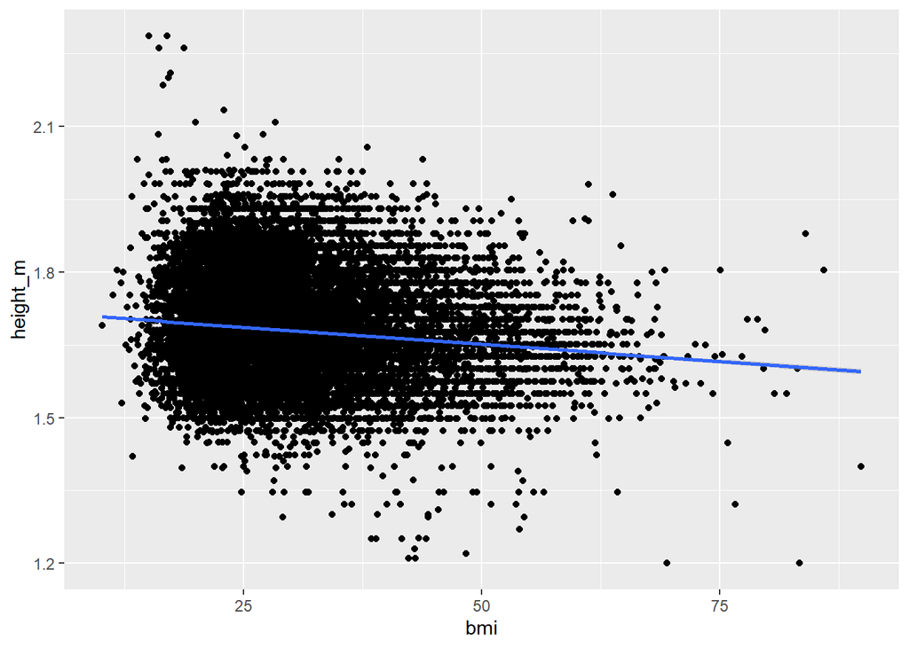

```r
dat %>%
ggplot(
  aes(x=bmi, y=height_m)) +
  geom_point()+
  geom_smooth(method=lm)
```

# 9 Ethnicity

```r
dat %>%
  freq(dem.what_is_your_ethnic_origin)
```

```
Frequencies
dat$dem.what_is_your_ethnic_origin
Type: Factor

                                Freq   % Valid   % Valid Cum.   % Total   % Total Cum.
---------------------------- ------- --------- -------------- --------- --------------
       Seen but not answered       0      0.00           0.00      0.00           0.00
           Prefer not to say      95      0.18           0.18      0.17           0.17
                  Don't know      65      0.12           0.30      0.12           0.29
                       White   50251     93.41          93.71     90.06          90.34
                       Mixed    1471      2.73          96.44      2.64          92.98
      Asian or Asian British     936      1.74          98.18      1.68          94.66
      Black or Black British     347      0.65          98.83      0.62          95.28
                        Arab      62      0.12          98.94      0.11          95.39
                       Other     570      1.06         100.00      1.02          96.41
                        <NA>    2002                               3.59         100.00
                       Total   55799    100.00         100.00    100.00         100.00
```

```r
dat <- dat %>%
  mutate(
    ethnicity =
      case_when(
        dem.what_is_your_ethnic_origin %in% c(
          "Prefer not to say",
          "Don't know",
          "Seen but not answered") ~ NA_character_,
        dem.what_is_your_ethnic_origin %in% c("Asian or Asian British", "Arab") ~
          "Asian, Asian British, Arab",
        TRUE ~ as.character(dem.what_is_your_ethnic_origin)
      ) %>% forcats::fct_infreq()
  )
```

```r
dat %>%
  freq(ethnicity)
```

```
Frequencies
dat$ethnicity
Type: Factor

                                    Freq   % Valid   % Valid Cum.   % Total   % Total Cum.
-------------------------------- ------- --------- -------------- --------- --------------
                           White   50251     93.69          93.69     90.06          90.06
                           Mixed    1471      2.74          96.43      2.64          92.69
      Asian, Asian British, Arab     998      1.86          98.29      1.79          94.48
                           Other     570      1.06          99.35      1.02          95.50
          Black or Black British     347      0.65         100.00      0.62          96.13
                            <NA>    2162                               3.87         100.00
                           Total   55799    100.00         100.00    100.00         100.00
```

```r
dat %>%
  freq(dem.what_is_your_sexual_orientation)
```

```
Frequencies
dat$dem.what_is_your_sexual_orientation
Type: Factor

                               Freq   % Valid   % Valid Cum.   % Total   % Total Cum.
--------------------------- ------- --------- -------------- --------- --------------
      Seen but not answered       0      0.00           0.00      0.00           0.00
       Prefer not to answer     919      1.68           1.68      1.65           1.65
               Heterosexual   39591     72.46          74.14     70.95          72.60
                 Homosexual    3405      6.23          80.37      6.10          78.70
                   Bisexual    8221     15.05          95.42     14.73          93.44
                    Asexual     709      1.30          96.71      1.27          94.71
                Self-define    1795      3.29         100.00      3.22          97.92
                      Other       0      0.00         100.00      0.00          97.92
                       <NA>    1159                               2.08         100.00
                      Total   55799    100.00         100.00    100.00         100.00
```

# 10 Sexual orientation

The “Other” category should be kept depending on research question and available data. In this case, no one answered “Other”.

```r
dat <- dat %>%
  mutate(
    sexual_orientation =
      if_else(
        condition = dem.what_is_your_sexual_orientation %in%
          c("Prefer not to answer",
          "Don't know",
          "Seen but not answered",
          "Other"
          ),
        true = NA_character_,
        false = as.character(dem.what_is_your_sexual_orientation),
        missing = NA_character_
      ) %>% forcats::fct_infreq()
  )
```

```r
dat %>%
  freq(sexual_orientation)
```

```
Frequencies
dat$sexual_orientation
Type: Factor

                      Freq   % Valid   % Valid Cum.   % Total   % Total Cum.
------------------ ------- --------- -------------- --------- --------------
      Heterosexual   39591     73.70          73.70     70.95          70.95
          Bisexual    8221     15.30          89.00     14.73          85.69
        Homosexual    3405      6.34          95.34      6.10          91.79
       Self-define    1795      3.34          98.68      3.22          95.01
           Asexual     709      1.32         100.00      1.27          96.28
              <NA>    2078                               3.72         100.00
             Total   55799    100.00         100.00    100.00         100.00
```

# 11 Highest education

```r
dat %>%
  summarytools::freq(dem.highest_education_finegrained)
```

```
Frequencies
dat$dem.highest_education_finegrained
Type: Factor

                                          Freq   % Valid   % Valid Cum.   % Total   % Total Cum.
-------------------------------------- ------- --------- -------------- --------- --------------
                     None of the above    1462      2.75           2.75      2.62           2.62
                    CSEs or equivalent     901      1.70           4.45      1.61           4.23
          O-levels/GCSEs or equivalent    5877     11.07          15.52     10.53          14.77
             NVQ/HND/HNC or equivalent    4593      8.65          24.17      8.23          23.00
      AS-levels/A-levels or equivalent   11939     22.48          46.65     21.40          44.40
       University degree or equivalent   28326     53.35         100.00     50.76          95.16
                                  <NA>    2701                               4.84         100.00
                                 Total   55799    100.00         100.00    100.00         100.00
```

```r
dat %>%
  summarytools::freq(dem.highest_education_collapsed)
```

```
Frequencies
dat$dem.highest_education_collapsed
Type: Factor

                                           Freq   % Valid   % Valid Cum.   % Total   % Total Cum.
--------------------------------------- ------- --------- -------------- --------- --------------
                      None of the above    1462      2.75           2.75      2.62           2.62
      GCSEs/CSEs/O-levels or equivalent    6778     12.77          15.52     12.15          14.77
              NVQ/HND/HNC or equivalent    4593      8.65          24.17      8.23          23.00
       A-levels/AS-levels or equivalent   11939     22.48          46.65     21.40          44.40
                             University   28326     53.35         100.00     50.76          95.16
                                   <NA>    2701                               4.84         100.00
                                  Total   55799    100.00         100.00    100.00         100.00
```

## 11.1 Cross table with employment

```r
dat %>%
  gtsummary::tbl_cross(
    row = dem.what_is_your_current_employment_status,
    col = dem.highest_education_finegrained, percent = "row")
```

|  | dem.highest_education_finegrained None of the above | dem.highest_education_finegrained CSEs or equivalent | dem.highest_education_finegrained O-levels/GCSEs or equivalent | dem.highest_education_finegrained NVQ/HND/HNC or equivalent | dem.highest_education_finegrained AS-levels/A-levels or equivalent | dem.highest_education_finegrained University degree or equivalent | dem.highest_education_finegrained Unknown | Total |  |
| --- | --- | --- | --- | --- | --- | --- | --- | --- | --- |
| dem.what_is_your_current_employment_status |  |  |  |  |  |  |  |  |  |
| Seen but not answered | 0 (NA%) | 0 (NA%) | 0 (NA%) | 0 (NA%) | 0 (NA%) | 0 (NA%) | 0 (NA%) | 0 (NA%) |  |
| Prefer not to answer | 14 (8.0%) | 3 (1.7%) | 34 (20%) | 15 (8.6%) | 29 (17%) | 71 (41%) | 8 (4.6%) | 174 (100%) |  |
| In paid employment or self-employed | 280 (0.9%) | 380 (1.2%) | 2,247 (7.1%) | 2,665 (8.4%) | 5,864 (19%) | 19,795 (63%) | 431 (1.4%) | 31,662 (100%) |  |
| Retired | 215 (6.7%) | 91 (2.8%) | 434 (13%) | 266 (8.3%) | 470 (15%) | 1,627 (51%) | 112 (3.5%) | 3,215 (100%) |  |
| Looking after home and/or family | 99 (5.4%) | 61 (3.4%) | 288 (16%) | 244 (13%) | 385 (21%) | 726 (40%) | 17 (0.9%) | 1,820 (100%) |  |
| Unable to work because of sickness or disability | 471 (7.3%) | 247 (3.8%) | 1,188 (18%) | 940 (14%) | 1,369 (21%) | 2,188 (34%) | 82 (1.3%) | 6,485 (100%) |  |
| Unemployed | 180 (7.5%) | 67 (2.8%) | 423 (18%) | 234 (9.7%) | 508 (21%) | 970 (40%) | 30 (1.2%) | 2,412 (100%) |  |
| Doing unpaid or voluntary work | 23 (2.8%) | 12 (1.5%) | 114 (14%) | 79 (9.8%) | 184 (23%) | 381 (47%) | 16 (2.0%) | 809 (100%) |  |
| Full or part-time student | 143 (2.1%) | 33 (0.5%) | 1,070 (16%) | 113 (1.7%) | 3,029 (45%) | 2,343 (35%) | 36 (0.5%) | 6,767 (100%) |  |
| None of the above | 35 (7.3%) | 7 (1.5%) | 79 (16%) | 36 (7.5%) | 97 (20%) | 212 (44%) | 14 (2.9%) | 480 (100%) |  |
| Unknown | 2 (0.1%) | 0 (0%) | 0 (0%) | 1 (<0.1%) | 4 (0.2%) | 13 (0.7%) | 1,955 (99%) | 1,975 (100%) |  |
| Total | 1,462 (2.6%) | 901 (1.6%) | 5,877 (11%) | 4,593 (8.2%) | 11,939 (21%) | 28,326 (51%) | 2,701 (4.8%) | 55,799 (100%) |  |

# 12 PHQ9

```r
dat %>%
  select(contains("phq9.")) %>%
  names
```

```
 [1] "phq9.dead_hurting_thoughts"
 [2] "phq9.feeling_bad_failure_family"
 [3] "phq9.feeling_down_depressed_or_hopeless"
 [4] "phq9.feeling_tired_or_having_little_energy"
 [5] "phq9.little_interest_or_pleasure_in_doing_things"
 [6] "phq9.moving_fidgety_noticed_opposite"
 [7] "phq9.poor_appetite_or_overeating"
 [8] "phq9.staying_asleep_sleeping_trouble"
 [9] "phq9.trouble_concentrating_reading_newspaper"
[10] "phq9.dead_hurting_thoughts_numeric"
[11] "phq9.feeling_bad_failure_family_numeric"
[12] "phq9.feeling_down_depressed_or_hopeless_numeric"
[13] "phq9.feeling_tired_or_having_little_energy_numeric"
[14] "phq9.little_interest_or_pleasure_in_doing_things_numeric"
[15] "phq9.moving_fidgety_noticed_opposite_numeric"
[16] "phq9.poor_appetite_or_overeating_numeric"
[17] "phq9.staying_asleep_sleeping_trouble_numeric"
[18] "phq9.trouble_concentrating_reading_newspaper_numeric"
[19] "phq9.sum_score"
[20] "phq9.binary_depression"
[21] "phq9.binary_depression_numeric"
[22] "phq9.severity_threshold"
[23] "phq9.severity_threshold_numeric"
```

## 12.1 Calculate Cronbach’s alpha

```r
alpha_results <- psych::alpha(
  x = dat_phq9,
  n.iter = 1000,
  use = "pairwise.complete.obs"#,
  #  check.keys = TRUE,  # This is to take into account those variables that are reverse coded/negatively related.
  )
```

```
Number of categories should be increased  in order to count frequencies.
```

```r
alpha_results
```

```
Reliability analysis
Call: psych::alpha(x = dat_phq9, n.iter = 1000, use = "pairwise.complete.obs")

  raw_alpha std.alpha G6(smc) average_r S/N     ase mean sd median_r
      0.92      0.92    0.92      0.56  11 0.00053 0.49 20     0.56

    95% confidence boundaries
             lower alpha upper
Feldt         0.91  0.92  0.92
Duhachek      0.91  0.92  0.92
bootstrapped  0.89  0.92  0.94

 Reliability if an item is dropped:
                                                         raw_alpha std.alpha
phq9.dead_hurting_thoughts_numeric                            0.91      0.91
phq9.feeling_bad_failure_family_numeric                       0.90      0.91
phq9.feeling_down_depressed_or_hopeless_numeric               0.91      0.91
phq9.feeling_tired_or_having_little_energy_numeric            0.90      0.91
phq9.little_interest_or_pleasure_in_doing_things_numeric      0.91      0.92
phq9.moving_fidgety_noticed_opposite_numeric                  0.91      0.91
phq9.poor_appetite_or_overeating_numeric                      0.90      0.91
phq9.staying_asleep_sleeping_trouble_numeric                  0.90      0.91
phq9.trouble_concentrating_reading_newspaper_numeric          0.90      0.91
                                                         G6(smc) average_r  S/N
phq9.dead_hurting_thoughts_numeric                          0.91      0.57 10.6
phq9.feeling_bad_failure_family_numeric                     0.90      0.54  9.6
phq9.feeling_down_depressed_or_hopeless_numeric             0.91      0.56 10.4
phq9.feeling_tired_or_having_little_energy_numeric          0.90      0.55  9.9
phq9.little_interest_or_pleasure_in_doing_things_numeric    0.91      0.58 11.0
phq9.moving_fidgety_noticed_opposite_numeric                0.90      0.56 10.1
phq9.poor_appetite_or_overeating_numeric                    0.90      0.55  9.8
phq9.staying_asleep_sleeping_trouble_numeric                0.90      0.55  9.7
phq9.trouble_concentrating_reading_newspaper_numeric        0.90      0.55  9.7
                                                         alpha se  var.r med.r
phq9.dead_hurting_thoughts_numeric                        0.00056 0.0049  0.59
phq9.feeling_bad_failure_family_numeric                   0.00063 0.0045  0.55
phq9.feeling_down_depressed_or_hopeless_numeric           0.00058 0.0056  0.58
phq9.feeling_tired_or_having_little_energy_numeric        0.00061 0.0045  0.56
phq9.little_interest_or_pleasure_in_doing_things_numeric  0.00056 0.0035  0.59
phq9.moving_fidgety_noticed_opposite_numeric              0.00060 0.0050  0.56
```

[output cut: 10 more lines]

```
phq9.little_interest_or_pleasure_in_doing_things_numeric 52571  0.69  0.69
phq9.moving_fidgety_noticed_opposite_numeric             52571  0.79  0.78
phq9.poor_appetite_or_overeating_numeric                 52571  0.81  0.81
phq9.staying_asleep_sleeping_trouble_numeric             52571  0.80  0.81
phq9.trouble_concentrating_reading_newspaper_numeric     52571  0.81  0.81
                                                         r.cor r.drop  mean sd
phq9.dead_hurting_thoughts_numeric                        0.68   0.65 -0.58 32
phq9.feeling_bad_failure_family_numeric                   0.81   0.77  0.70 25
phq9.feeling_down_depressed_or_hopeless_numeric           0.70   0.67  0.50 26
phq9.feeling_tired_or_having_little_energy_numeric        0.78   0.74  1.36 22
phq9.little_interest_or_pleasure_in_doing_things_numeric  0.64   0.61  0.58 24
phq9.moving_fidgety_noticed_opposite_numeric              0.75   0.71 -0.45 30
phq9.poor_appetite_or_overeating_numeric                  0.78   0.75  0.57 27
phq9.staying_asleep_sleeping_trouble_numeric              0.79   0.75  1.11 23
phq9.trouble_concentrating_reading_newspaper_numeric      0.79   0.75  0.59 25
```

```r
ltm::cronbach.alpha(
  data = dat_phq9,
  CI = TRUE,
  na.rm = TRUE)
```

```
Cronbach's alpha for the 'dat_phq9' data-set

Items: 9
Sample units: 55799
alpha: 0.915

Bootstrap 95% CI based on 1000 samples
 2.5% 97.5%
0.883 0.934
```

Inspect phq9.dead_hurting_thoughts_numeric

```r
dat %>%
  summarytools::freq(
    phq9.dead_hurting_thoughts_numeric
  )
```

```
Frequencies
dat$phq9.dead_hurting_thoughts_numeric
Type: Numeric

               Freq   % Valid   % Valid Cum.   % Total   % Total Cum.
----------- ------- --------- -------------- --------- --------------
       -777      90      0.17           0.17      0.16           0.16
          0   28739     54.67          54.84     51.50          51.67
          1   13350     25.39          80.23     23.93          75.59
          2    5098      9.70          89.93      9.14          84.73
          3    5294     10.07         100.00      9.49          94.21
       <NA>    3228                               5.79         100.00
      Total   55799    100.00         100.00    100.00         100.00
```

## 12.2 Binary Q9 suicide

Thoughts that you would be better off dead, or of hurting yourself in some way? Not at all Several days More than half the days Nearly every day

```r
dat <- dat %>%
  mutate(
    phq.Q9_suicidality_binary_numeric =
      recode_factor(
        phq9.dead_hurting_thoughts_numeric,
        `-777` = NA_real_,
        `0` = 0,
        `1` = 1,
        `2` = 1,
        `3` = 1
        )
    )

dat %>%
  summarytools::freq(phq.Q9_suicidality_binary_numeric,
    cumul = FALSE,
    round.digits = 1
    )
```

```
Frequencies
dat$phq.Q9_suicidality_binary_numeric
Type: Factor

               Freq   % Valid   % Total
----------- ------- --------- ---------
          0   28739      54.8      51.5
          1   23742      45.2      42.5
       <NA>    3318                 5.9
      Total   55799     100.0     100.0
```

```r
dat <- dat %>%
  mutate(
    phq.Q9_suicidality_binary =
      recode_factor(
        phq.Q9_suicidality_binary_numeric,
        `0` = "No suicidality",
        `1` = "Any suicidality"
        )
    )

dat %>%
  summarytools::freq(phq.Q9_suicidality_binary,
    cumul = FALSE,
    round.digits = 1
    )
```

```
Frequencies
dat$phq.Q9_suicidality_binary
Type: Factor

                         Freq   % Valid   % Total
--------------------- ------- --------- ---------
       No suicidality   28739      54.8      51.5
      Any suicidality   23742      45.2      42.5
                 <NA>    3318                 5.9
                Total   55799     100.0     100.0
```

# 13 Mental Health Diagnoses

```r
dat %>%
  select(
    contains("mhd.")
  ) %>%
  names
```

```
  [1] "mhd.prevented_mental_distress_usual"
  [2] "mhd.unusual_experiences_seek_receive"
  [3] "mhd.mdd"
  [4] "mhd.perinatal_depression"
  [5] "mhd.pmdd"
  [6] "mhd.bipolar_disorder"
  [7] "mhd.gad"
  [8] "mhd.social_anxiety"
  [9] "mhd.specific_phobia_"
 [10] "mhd.agoraphobia"
 [11] "mhd.panic_disorder"
 [12] "mhd.panic_attacks"
 [13] "mhd.ptsd"
 [14] "mhd.ocd"
 [15] "mhd.bdd"
```

[output cut: 149 more lines]

## 13.1 Psychiatric diagnoses selection

Psychiatric disorders vectors

```r
psy_dx_factors <- c(
  "mhd.mdd",
  "mhd.gad",
  "mhd.social_anxiety",
  "mhd.specific_phobia_",
  "mhd.agoraphobia",
  "mhd.panic_disorder",
  "mhd.panic_attacks",
  "mhd.bipolar_disorder",
  "mhd.bdd",
  "mhd.an",
  "mhd.atypical_an",
  "mhd.bn",
  "mhd.bed"
)

psy_dx_numeric <- c(
  "mhd.mdd_numeric",
  "mhd.gad_numeric",
  "mhd.social_anxiety_numeric",
  "mhd.specific_phobia_numeric",
  "mhd.agoraphobia_numeric",
  "mhd.panic_disorder_numeric",
  "mhd.panic_attacks_numeric",
  "mhd.bipolar_disorder_numeric",
  "mhd.bdd_numeric",
  "mhd.an_numeric",
  "mhd.atypical_an_numeric",
  "mhd.bn_numeric",
  "mhd.bed_numeric"
)
```

Drop empty levels

```r
dat_psy_dx <- dat %>%
  select(
    all_of(psy_dx_factors)
  ) %>%
  mutate(across(where(is.factor), fct_drop))
```

```r
dat_psy_dx %>%
  summarytools::freq()
```

```
Frequencies
dat_psy_dx$mhd.mdd
Type: Factor

                 Freq   % Valid   % Valid Cum.   % Total   % Total Cum.
------------- ------- --------- -------------- --------- --------------
      Not MDD    7014     13.27          13.27     12.57          12.57
          MDD   45859     86.73         100.00     82.19          94.76
         <NA>    2926                               5.24         100.00
        Total   55799    100.00         100.00    100.00         100.00

dat_psy_dx$mhd.gad
Type: Factor

                 Freq   % Valid   % Valid Cum.   % Total   % Total Cum.
------------- ------- --------- -------------- --------- --------------
      Not GAD   12505    100.00         100.00     22.41          22.41
         <NA>   43294                              77.59         100.00
        Total   55799    100.00         100.00    100.00         100.00

dat_psy_dx$mhd.social_anxiety
Type: Factor

                            Freq   % Valid   % Valid Cum.   % Total   % Total Cum.
------------------------ ------- --------- -------------- --------- --------------
      Not Social anxiety   39985    100.00         100.00     71.66          71.66
                    <NA>   15814                              28.34         100.00
                   Total   55799    100.00         100.00    100.00         100.00

dat_psy_dx$mhd.specific_phobia_
Type: Factor

                              Freq   % Valid   % Valid Cum.   % Total   % Total Cum.
-------------------------- ------- --------- -------------- --------- --------------
      Not Specific phobia·   50180    100.00         100.00     89.93          89.93
                      <NA>    5619                              10.07         100.00
                     Total   55799    100.00         100.00    100.00         100.00

dat_psy_dx$mhd.agoraphobia
Type: Factor
```

[output cut: 64 more lines]

```

                Freq   % Valid   % Valid Cum.   % Total   % Total Cum.
------------ ------- --------- -------------- --------- --------------
      Not BN   50757    100.00         100.00     90.96          90.96
        <NA>    5042                               9.04         100.00
       Total   55799    100.00         100.00    100.00         100.00

dat_psy_dx$mhd.bed
Type: Factor

                 Freq   % Valid   % Valid Cum.   % Total   % Total Cum.
------------- ------- --------- -------------- --------- --------------
      Not BED   49958    100.00         100.00     89.53          89.53
         <NA>    5841                              10.47         100.00
        Total   55799    100.00         100.00    100.00         100.00
```

# 14 Selection of variables

```r
dat %>%
  names
```

```
  [1] "ID"
  [2] "startDate.x"
  [3] "endDate.x"
  [4] "sample"
  [5] "dem.how_old_are_you_now.txt"
  [6] "dem.dob_age"
  [7] "dem.age_match"
  [8] "dem.age_likely"
  [9] "dem.age_category"
 [10] "dem.age_category_numeric"
 [11] "startDate.y"
 [12] "endDate.y"
 [13] "dem.what_is_your_current_employment_status"
 [14] "dem.what_is_your_current_employment_status_numeric"
 [15] "startDate.x.x"
```

[output cut: 264 more lines]

```r
dat_rds <- dat %>%
  select(
    "ID",
    "gad7.sum_score",
    all_of(gad7_items_numeric),

    "phq9.sum_score",
    "phq.Q9_suicidality_binary_numeric", # Suicidality
    "phq.Q9_suicidality_binary",
    all_of(phq9_items_numeric),
    all_of(phq9_items),

    "gender",
    "age",
    "bmi",
    "height_m",
    "ethnicity",
    "sexual_orientation",
    "dem.highest_education_finegrained",
    "dem.highest_education_collapsed",
  ) %>%
  bind_cols(
    dat_psy_dx
  )

dat_rds %>%
  names
```

```
 [1] "ID"
 [2] "gad7.sum_score"
 [3] "gad7.feeling_nervous_anxious_or_on_edge_numeric"
 [4] "gad7.control_worrying_stop_numeric"
 [5] "gad7.worrying_too_much_about_different_things_numeric"
 [6] "gad7.trouble_relaxing_numeric"
 [7] "gad7.sit_restless_hard_numeric"
 [8] "gad7.becoming_easily_annoyed_or_irritable_numeric"
 [9] "gad7.awful_feeling_afraid_happen_numeric"
[10] "phq9.sum_score"
[11] "phq.Q9_suicidality_binary_numeric"
[12] "phq.Q9_suicidality_binary"
[13] "phq9.dead_hurting_thoughts_numeric"
[14] "phq9.feeling_bad_failure_family_numeric"
[15] "phq9.feeling_down_depressed_or_hopeless_numeric"
```

[output cut: 36 more lines]

# 15 Write rds file after variable creation

```r
write_rds(
  x = dat_rds,
  file = paste0(filepath_cleaned_data,"dat_variable_creation", date, ".rds")
                )
```